# ufc

Kenny Darrell

November 8, 2014

### History

Mixed Martial Arts (MMA) is a new sport, but it has grown pretty fast. I remember being young and seeing advertisments for the first UFC event. Being a kid from the eighties who enjoyed profesional wrestling I was pretty fascinated. It was a different beast back then in the early ninties. It has evolved into a very large and organized sport.

There are also different organizations in this realm, [Bellator](http://www.bellator.com/), [PRIDE](http://en.wikipedia.org/wiki/Pride_Fighting_Championships) and [UFC](http://www.ufc.com/).

For many reasons this interests me. If you have read any of my past blogs you can see lots if topics related to sports. My other intersts of temoral data and network data are both very appearent here. (Needs more)

### ESPN

There are quite a few sources for information in this area. Some are pretty explicit about not scrpping data and others seem to be more open. There is alot of data on [ESPN](http://espn.go.com/mma/). To pull this data I used the new rvest package which made things very easy than other methods I have used in the past. I tried to use some of the newer webscriping tools but ran into some issues. I hope that these tools continue to evolve, and perhaps I should retry or try others to see which ones are more capable, perhaps a blog for another day.

Using rvest and dplyr together makes the code look like a pipeline, very clean and readable.

```r
'http://espn.go.com/mma/fighters' %>%
  html() %>%
  html_nodes('.evenrow, a') %>%
  html_attrs() %>%
  grep('/fighter/', ., value = T) %>%
  sapply(function(x) x[[1]]) %>%
  as.character() %>%
  head()
```

```
## [1] "/mma/fighter/_/id/3043549/niina-aaltonen"
## [2] "/mma/fighter/_/id/2504991/tom-aaron"
## [3] "/mma/fighter/_/id/3088828/joshua-aarons"
## [4] "/mma/fighter/_/id/3089919/mike-aarts"
## [5] "/mma/fighter/_/id/2511451/zyad-abada"
## [6] "/mma/fighter/_/id/2966179/kadzhik-abadzhyan"
```

```r
'http://espn.go.com/mma/fighter/history/_/id/3031574/matthew-lozano' %>%
  html() %>%
  html_nodes('div div div .evenrow td') %>%
  html_text() %>%
  matrix(ncol = 7, byrow = T) %>%
  data.frame() %>%
  select(date = X1, opponent = X3, result = X4, method = X5, time = X7)
```

```
##           date      opponent result                      method time
## 1 Oct 11, 2013   Klayton Mai    Win Submission (Triangle Choke) 1:14
## 2 Oct 19, 2012   Dave Morgan    Win Submission (Triangle Choke) 2:28
## 3 Jun 29, 2012 Joshua Aarons    Win Submission (Triangle Choke) 4:23
```

```r
'http://espn.go.com/mma/fighter/stats/_/id/3031574/matthew-lozano' %>%
  html() %>%
  html_nodes('.general-info li') %>%
  html_text()
```

```
## [1] "Bantamweight"    "5'7\", 135 lbs."
```

```r
load('final_espn.RData')

head(fights)
```

```
##        id       date                                     event
## 1 3032062 2011-09-03             One FC: Champion vs. Champion
## 2 3032062 2010-09-24 Legend FC: Legend Fighting Championship 3
## 3 3050604 2010-02-21     GC: Gladiator Challenge: Vision Quest
## 4 2557041 2009-08-15          Called Out MMA: Called Out MMA 1
## 5 2499256 2004-12-18                       CWFC 9: Xtreme Xmas
## 6 2504979 2010-05-07                       MFC 25: Vindication
##                opp result                  dec round time   oppid exp
## 1  eduard folayang   Loss Decision - Unanimous     3 5:00 2975101   2
## 2    guangyou ning    Win   Unanimous Decision     3 5:00 2996677   1
## 3      john robles   Loss                   KO     1 0:48 3044362   1
## 4 francisco rivera   Loss    Majority Decision     3 5:00 2531855   1
## 5        dan hardy   Loss                   KO     1 0:13 2354205   1
## 6       keto allen   Loss                  TKO     1 2:58 2504978   1
```

The first thing that I thought would be useful is to build a model that can predict the outcome of a given fight. There are a few reasons why this problem is different than building a typical model. The most important reason is that each observation is not independent. This lack of independence happens on many levels. First if I have a fight to predict I actually have it setup as two fights now, one from each fighter. I cannot predict the outcome of the fight like this, What if I have a model that says both fighters win. There is also a larger network effect, any given fight could have fighters that have fought in many other fights, maybe even a clone of the fight under consideration.

### Restructure

The first step is to resolve the issue of each fight really having two different observations, one from each side. I started writing code to this and it turned out to be very, very gross. It was hard to grapple in my head. Weird things had to happen, I had to join the data on itself but change the names of fieds to get over the collision of the fighter attributes. One thing I want to address here, which I have spoke about some in the past is using the right tool for the job. After started down the path of trying this I realized this appraoch was all wrong. Here is a glimse of waht that code looked like, pretty ugly.

```r
# Make names with winner and loser
fights$winner <- ifelse(fights$result == 'Win', fights$name, fights$opp)
fights$loser <- ifelse(fights$result == 'Loss', fights$name, fights$opp)

# Now remove opponent field
fights$opp <- NULL

# need to create two tables, one will have the data for winner and one the loser
left <- fights[fights$result == 'Win', c(1, 3:7, 2, 8:9)]
right <- fights[fights$result == 'Loss', c(1, 3:7, 2, 8:9)]

# Change the names of each to denote fields realtion.
names(left)[1:6] <- paste('wn_', names(left)[1:6], sep = '')
names(right)[1:6] <- paste('ls_', names(right)[1:6], sep = '')

left <- left[order(left$date), ]
right <- right[order(right$date), ]

# Create a table of atomic fight data.
key <- fights[, c('date', 'winner', 'loser')]
key <- unique(key)

# This joins the left and right side (winner/loser) data on
join <- merge(key, left, by = c('date', 'winner', 'loser'))
join <- merge(join, right, by = c('date', 'winner', 'loser'))

# We should have two rows for each
join <- unique(join)

# No longer have becuase we have winner and loser fields.
join$wn_name <- NULL
join$ls_name <- NULL
join$wn_result <- NULL
join$ls_result <- NULL

# Create an id for each fight
join$matchid <- as.character(1:nrow(join) + 100000)

# Cleanup tables.
rm(key, left, right)

# Now we have to merge the bio data on for both the winner and loser.
pl_lk <- data
pl_lk$name <- NULL

# Need to rename everything
names(pl_lk) <- paste('wn_', names(pl_lk), sep = '')
join2 <- merge(join, pl_lk, by = 'wn_id')

# Redo for loser and switch names
names(pl_lk) <- gsub('wn_', 'ls_', names(pl_lk))
join3 <- merge(join2, pl_lk, by = 'ls_id')

# Finally have the right structure
fight <- join3
```

This seems like a perfect place to use Neo4j. I can give it each fighteres data and then create a relation for each fight. Then I can just query for teh data I want and in the right format. Shove all of my data into Neo4j and have cypher do all of the messy parts behind the scenes, perfect.

I created some code that sits on top of the RNeo4j package so that you can add whole tables with given realtionships, whcih there may now be some new commits that allwo you to do this. I just llop through the fighter attribute data adn the fight data adding everything.

```r
graph = startGraph("http://localhost:7474/db/data/")

person <- add_nodes(data, c('fighter', 'espn'), 'id', props = names(data))

add_rels(fights, from = person, f_name = 'id', to = person, t_name = 'oppid',
         how = 'fought', props = c('date', 'result', 'dec', 'time'))
```

I can get the data I want by using a query like this.

```
MATCH (a)-[r:fought]->(b)
  WHERE r.result = "Win"
  RETURN a.name as wname, a.weight as ww, r.dec as dec, r.date as date,
         b.name as lname, b.weight as lw
UNION ALL MATCH (a)-[r:fought]->(b)
  WHERE r.result = "Loss"
  RETURN b.name as wname, b.weight as ww, r.dec as dec, r.date as date,
         a.name as lname, a.weight as lw;
```

I now just use the cypher function with this query passed in as a string and the data I want is returned.

```r
fight <- unique(cypher(graph, query))
```

### Investigate

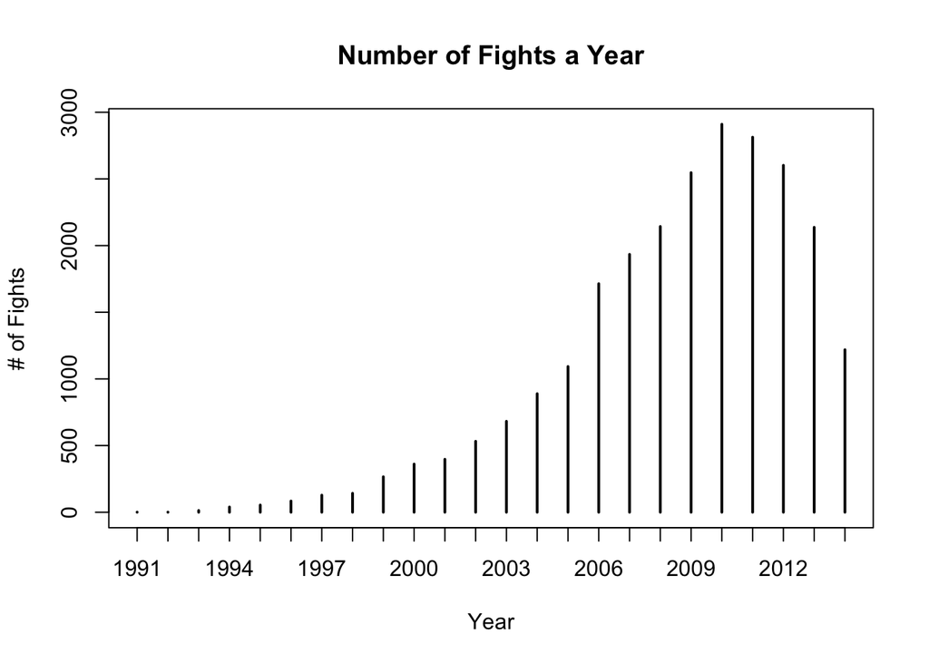

```r
# How many fights per year
fight %>% mutate(date = ymd(date), year = year(date)) -> fight

plot(table(fight$year), xlab = 'Year', ylab = '# of Fights',
     main = 'Number of Fights a Year')
```

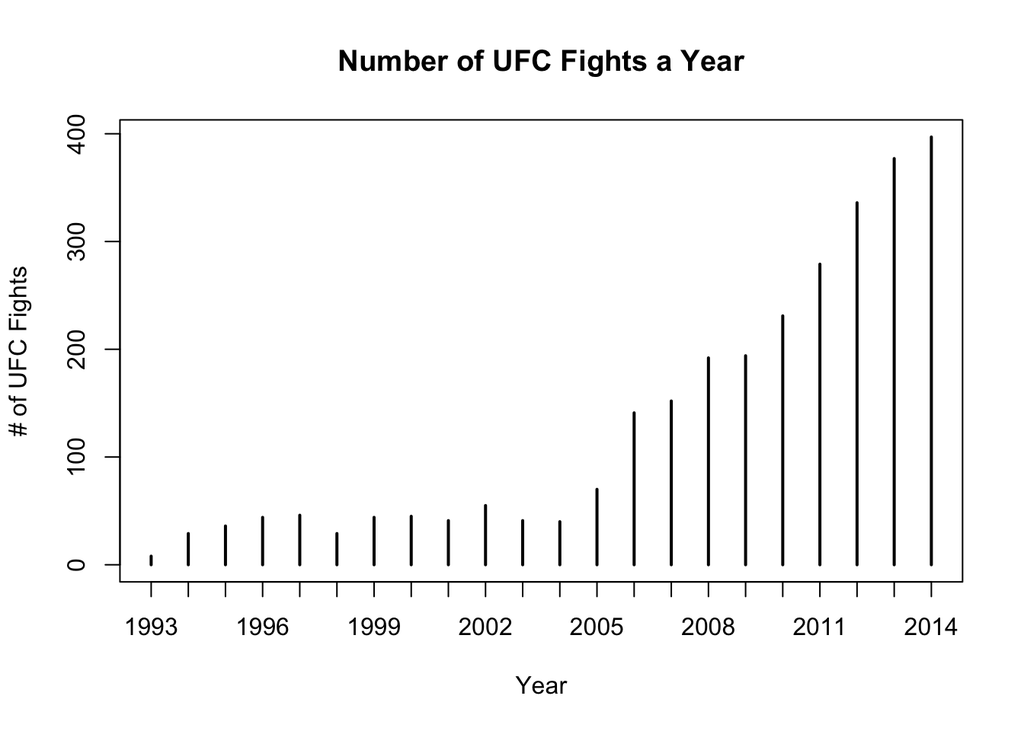

```r
ufc <- fight[grep('UFC', fight$event), ]
plot(table(ufc$year), xlab = 'Year', ylab = '# of UFC Fights',
     main = 'Number of UFC Fights a Year')
```

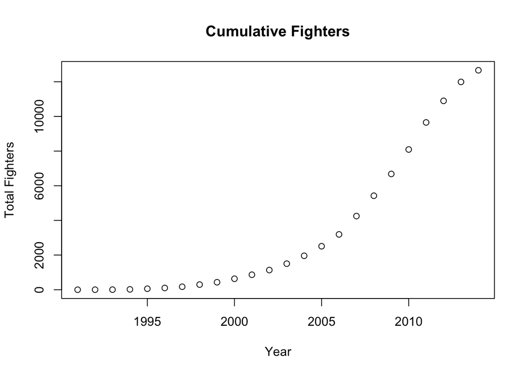

```r
# How has the network changed
y <- sort(unique(fight$year))


num_fg <- c()
for(i in y) {
  tmp <- fight[fight$year < i, ]
  num_fg <- c(num_fg, length(unique(c(tmp$wid, tmp$lid))))
}
plot(y, num_fg, xlab = 'Year', ylab = 'Total Fighters', main = 'Cumulative Fighters')
```

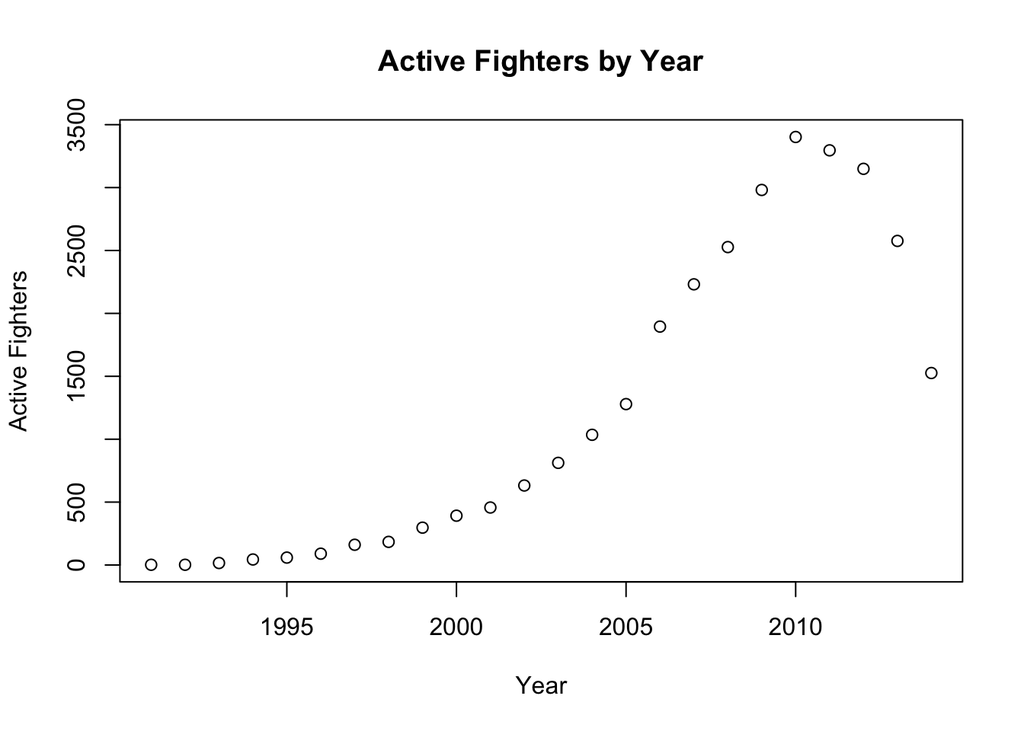

```r
num_fg <- c()
for(i in y) {
  tmp <- fight[fight$year == i, ]
  num_fg <- c(num_fg, length(unique(c(tmp$wid, tmp$lid))))
}
plot(y, num_fg, xlab = 'Year', ylab = 'Active Fighters', main = 'Active Fighters by Year')
```

```r
rm(tmp, i, num_fg, y)
```

### Missing data

```r
head(data)
```

```
##        id           name weight height         class country birth stance
## 1 3032062     a sol kwon   <NA>   <NA>          <NA>    <NA>  <NA>   <NA>
## 2 3050604 aaron anderson   <NA>   <NA>          <NA>    <NA>  <NA>   <NA>
## 3 2557041    aaron arana    135   <NA> Featherweight    <NA>  <NA>   <NA>
## 4 2499256   aaron barrow   <NA>   <NA>  Welterweight    <NA>  <NA>   <NA>
## 5 2504979    aaron berke   <NA>   <NA>  Welterweight    <NA>  <NA>   <NA>
## 6 3010409     aaron birn   <NA>   <NA>          <NA>    <NA>  <NA>   <NA>
##   nickname reach style
## 1     <NA>  <NA>  <NA>
## 2     <NA>  <NA>  <NA>
## 3     <NA>  <NA>  <NA>
## 4     <NA>  <NA>  <NA>
## 5     <NA>  <NA>  <NA>
## 6     <NA>  <NA>  <NA>
```

Once the data is setup you quickly realize that there are lots of holes. Most of the predictor variables you need are missing. What would be the best way to resolve this? I have a few thoughts. Pull data from another place that is more complete. This was my first thought. Two things to note. I had first hoped I could just pull data to repalce everything I had done, find a source with perfect data. This did not work out. Then I thought could I pull data for another source and merge the two togther. This would take mean I have two partial sources, say 25% and 35% complete. Could they be resolved into data that is closer to 60%. The answer is no and yes. I know they will not be complete opposites, they will have some overlap, so the combination should be more than either of the parts but less than the sum. How many sources are out there? Could you merge three or more together. Would this be a diminishing returns problem? This would lead to an entity resolution problem, and a tough one at that. There are some tools to help solve this problem, but that may be a challange for another day. It is getting close to the issue of waiting for perfect data. I think that getting more data and have a cleaner set would be valauble, but after fusing another set I may be on the same boat.

My second thought was, can I use network attributes for predictor varaibles. The cleanest part of the data is the collection of fights, its participants and the result. I started thinking of my posts on Social Balance. If A beats B, and B beats C should I be able to predict that A will beat C. Maybe, what if that was a long time ago. Can MMA exibit paper rock scissors type of effects. Maybe certain styles of fighting have weakeness to others. You could also be haivng an off day. This means we need to look at the network of fights. It also means that we need to look at how it evolved, not just how it exists today.

### First may be bet to look at network of one league

### second post can work on entity resolution

Code to create gephi file

```r
graph = startGraph("http://localhost:7474/db/data/")


q <- 'MATCH (a)-[r:fought]->(b)-[s:fought]->(a)
      WHERE r.result = "Win" and r.date = s.date
      RETURN a.name as wname, a.id as wid,
             r.date as date,
             b.name as lname, b.id as lid
      UNION ALL
      MATCH (a)-[r:fought]->(b)-[s:fought]->(a)
      WHERE r.result = "Loss" and r.date = s.date
      RETURN b.name as wname, b.id as wid,
             r.date as date,
             a.name as lname, a.id as lid;'

f <- unique(cypher(graph, q))

# Need the start of everynode
w <- f[, c('wid', 'wname', 'date')]
l <- f[, c('lid', 'lname', 'date')]

names(w) <- c('id', 'name', 'date')
names(l) <- c('id', 'name', 'date')
wl <- rbind(w, l)


wl %>%
  group_by(id, name) %>%
  summarise(start = min(date), end = max(data)) ->
  start

#############

write("", file = "tester2.gexf", append = FALSE)

log <- function(text) {
  write(text, file = "tester2.gexf", append = TRUE)
}

log('
<gexf xmlns="http://www.gexf.net/1.1draft"
xmlns:xsi="http://www.w3.org/2001/XMLSchema-instance"
xsi:schemaLocation="http://www.gexf.net/1.1draft
                             http://www.gexf.net/1.1draft/gexf.xsd"
version="1.1">
  <graph mode="dynamic" defaultedgetype="directed">
  <attributes class="node" mode="dynamic">
  <attribute id="price" title="Price" type="float"/>
  </attributes>
  <nodes>
')


log_node <- function(id, label, s, e) {
  first <- min(start$start)
  last <- max(start$end)
  s <- as.integer(difftime(s, first, units = 'days'))
  e <- as.integer(difftime(e, first, units = 'days'))
  end <- min(e+200, as.integer(difftime(last, first, units = 'days')))
  n <- paste('<node id="', id, '" label="', label,
             '" start="', s, '" end="', end, '" >', sep = '')
  log(n)
  log('</node>')
  NULL
}

for(i in 1:nrow(start)) {
  log_node(start$id[i], start$name[i], start$start[i], start$end[i])
  print(i)
}

log('  </nodes>')
log('  <edges>')

log_edge <- function(s, t, d) {
  d <- as.integer(difftime(d, min(start$start), units = 'days'))
  end <- min(d+200, as.integer(difftime(today(), min(start$start), units = 'days')))
  n <- paste('  <edge source="', s, '" target="', t, '" start="', d, '" end="', end, '"/>', sep = '')
  log(n)
  NULL
}


for(i in 1:nrow(f)) {
  log_edge(f$wid[i], f$lid[i], f$date[i])
  print(i)
}

log('  </edges>')
log(' </graph>')
log('</gexf>')
```

```r
graph = startGraph("http://localhost:7474/db/data/")

q <- '
MATCH (a)-[r:fought]->(b)-[s:fought]->(a)
WHERE r.result = "Win" and r.date = s.date
RETURN a.name as name, a.id as id, a.weight as weight, a.height as height,
       r.result as result, r.date as date, r.exp as exp, s.exp as oexp,
       b.id as oid, b.weight as oweight, b.height as oheight
UNION ALL
MATCH (a)-[r:fought]->(b)-[s:fought]->(a)
WHERE r.result = "Loss" and r.date = s.date
RETURN a.name as name, a.id as id, a.weight as weight, a.height as height,
       r.result as result, r.date as date, r.exp as exp, s.exp as oexp,
       b.id as oid, b.weight as oweight, b.height as oheight;'

f <- unique(cypher(graph, q))


# People usually do not win on there first fight
table(f[f$exp == 1, ]$result)
```

```
##
## Loss  Win
## 9932 2811
```

```r
table(f[f$exp == 2, ]$result)
```

```
##
## Loss  Win
## 3296 2040
```

```r
table(f[f$exp == 3, ]$result)
```

```
##
## Loss  Win
## 1752 1761
```

```r
w <- as.data.frame(table(f[f$result == 'Win', ]$exp))
l <- as.data.frame(table(f[f$result == 'Loss', ]$exp))

names(l)[2] <- 'Freq2'
winloss <- merge(w, l, all.x = T, all.y = T)
names(winloss) <- c('Experience', 'Win', 'Loss')
head(winloss, 10)
```

```
##    Experience  Win Loss
## 1           1 2811 9932
## 2           2 2040 3296
## 3           3 1761 1752
## 4           4 1510 1197
## 5           5 1395  893
## 6           6 1307  681
## 7           7 1218  575
## 8           8 1092  547
## 9           9 1044  486
## 10         10  945  447
```

```r
rm(w, l)

#
f$weight <- as.numeric(f$weight) - as.numeric(f$oweight)
# Weight does not seem to help much.
mean(f[f$result == 'Win', ]$weight, na.rm = T)
```

```
## [1] -1.482577
```

```r
sd(f[f$result == 'Win', ]$weight, na.rm = T)
```

```
## [1] 17.90397
```

```r
f$weight <- NULL
f$oweight <- NULL


f$height <- as.numeric(f$height) - as.numeric(f$oheight)
# Height does not help either.
mean(f[f$result == 'Win', ]$height, na.rm = T)
```

```
## [1] 0.1363392
```

```r
sd(f[f$result == 'Win', ]$height, na.rm = T)
```

```
## [1] 2.749247
```

```r
f$height <- NULL
f$oheight <- NULL


f$birth <- NULL
f$obirth <- NULL
```

So it seems the variables I thought at first would be useful had very little value. I still that there may be some value in other varaibles such as age and style but they are missing more often than not so. They are also other varaibles that I think may be useful like how you wone the fight and how long it took but first I want to check out the graph measures and see how they play out.

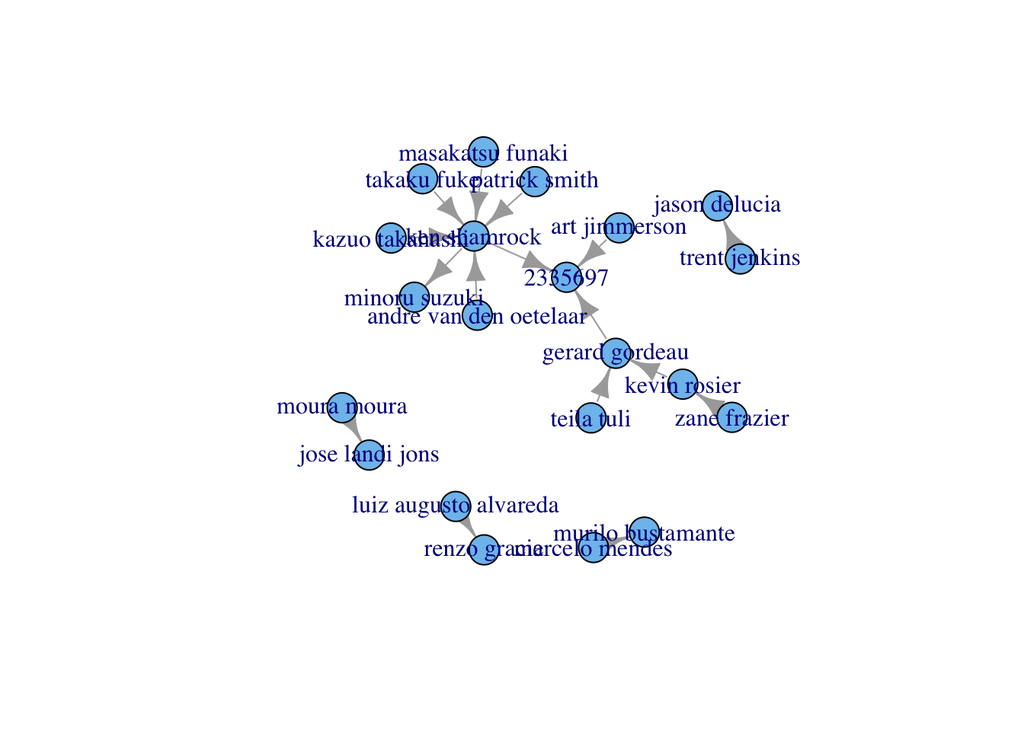

```r
grTab <- function(gr) {
  data.frame(        id = vertex.attributes(gr)$name,
              closeness = centralization.closeness(gr)$res,
             betweeness = betweenness(gr),
            eigenvector = centralization.evcent(gr)$vector,
                    hub = hub.score(gr)$vector,
                   auth = authority.score(gr)$vector,
                   page = page.rank(gr)$vector)
}


#source_url('https://raw.githubusercontent.com/darrkj/darrkj.github.io/master/rcode/import.R')
#import('igraph_2_d3')
#import('d3plot')


q2 <- 'MATCH (a)-[r:fought]->(b)
       WHERE r.result = "Win"
       RETURN a.id as id, a.name as name, r.date as date,
              b.id as oid, b.name as oname;'



q2 %>% cypher(graph, .) %>% unique() %>% mutate(date = ymd(date)) -> f2


time <- sort(unique(f2$date))
g <- graph.data.frame(f2[f2$date < time[10], c('oname', 'name')])


plot(g)
```

```r
#d3plot(g)



###############################

if(F) {

pageRank <- list()
for (i in 2:length(time)) {

  g <- graph.data.frame(f2[f2$date < time[i], c('oid', 'id')])
  y <- x <- cbind(grTab(g), date = time[i])
  names(x) <- c("id", "cl", "bet", "eig", "hub", "auth", "page", "date")
  names(y) <- c("oid", "ocl", "obet", "oeig", "ohub", "oauth", "opage", "date")

  tmp <- f2[f2$date == time[i], ]
  tmp <- merge(tmp, x, by = c('id', 'date'), all.x = T)
  tmp <- merge(tmp, y, by = c('oid', 'date'), all.x = T)

  pageRank[[as.character(i)]] <- tmp
  print(i)
}

pageRank <- recurBind(pageRank)[[1]]

}
rm(f2, q2)
load('pageRank.RData')
#

page <- pageRank[, c('page', 'opage')]
page <- page[complete.cases(page), ]
sum(page[, 1] < page[, 2])
```

```
## [1] 4052
```

```r
sum(page[, 1] > page[, 2])
```

```
## [1] 9119
```

```r
############################
#
# Create model dataset


p1 <- pageRank[, c('id', 'oid', 'date', 'cl', 'bet', 'eig', 'hub', 'auth', 'page')]
p2 <- pageRank[, c('oid', 'id', 'date', 'ocl', 'obet', 'oeig', 'ohub', 'oauth', 'opage')]
names(p2) <- c('id', 'oid', 'date', 'cl', 'bet', 'eig', 'hub', 'auth', 'page')

p <- rbind(p1, p2)
p$date <- as.character(p$date)


f2 <- merge(f, p, all.x = T)

names(p) <- c('oid', 'id', 'date', 'ocl', 'obet', 'oeig', 'ohub', 'oauth', 'opage')

f2 <- merge(f2, p, all.x = T)

f3 <- f2[, c("result", "exp", "oexp", "cl", "bet", "eig", "hub", "auth",
             "page", "ocl", "obet", "oeig", "ohub", "oauth", "opage")]


f3$y <- ifelse(f3$result == 'Win', 1, 0)
f3$result <- NULL



f3[is.na(f3)] <- 0

f3 %>%
  mutate(expDiff = exp - oexp, clDiff = cl - ocl, betDiff = bet - obet,
         eigDiff = eig - oeig, hubDiff = hub - ohub, authDiff = auth - oauth,
         pageDiff = page - opage) -> f3

#x <- f3[, c('date', 'id', 'oid', 'y')]
#x$date <- as.numeric(as.Date(x$date))

#xelo <- elo(x, history = TRUE)
```

```r
#######################################
#
# Sample
#
#######################################

n <- nrow(f3)

# 70 / 30 split
id <- sample(1:n, .7 * n)



train <- f3[id, ]
test <- f3[setdiff(1:n, id), ]



mod <- randomForest(y ~ ., data = train, ntree = 300, do.trace = 1)
```

[output not shown]

[output cut: 287 more lines]

```r
eval <- as.numeric(predict(mod, newdata = test, type = 'response'))


xp <- prediction(eval, test$y)
performance(xp, 'auc')
```

```
## An object of class "performance"
## Slot "x.name":
## [1] "None"
##
## Slot "y.name":
## [1] "Area under the ROC curve"
##
## Slot "alpha.name":
## [1] "none"
##
## Slot "x.values":
## list()
##
## Slot "y.values":
## [[1]]
## [1] 0.8330543
##
##
## Slot "alpha.values":
## list()
```

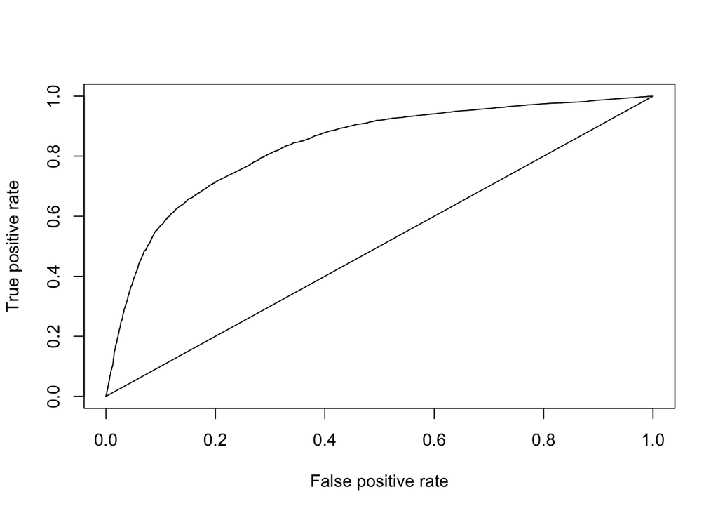

```r
pp <- performance(xp, "tpr","fpr")
plot(pp)
points(seq(0, 1, .01), seq(0, 1, .01), type = 'l')
```

```r
max(f2$date)
```

```
## [1] "2014-11-02"
```

```r
#"2014-11-02"
```

```r
clean <- function(x) {
  x %>% html_attrs() %>% sapply(function(x) x[[1]]) %>% as.character() %>%
    gsub('http://espn.go.com/mma/fighter/_/id/', '', .) %>% strsplit('/') %>%
    sapply(function(x) x[[1]][1])
}

get_event <- function(url) {
  url %>% html() -> html

  html %>% html_nodes('.winner') %>% html_attrs() %>%
    sapply(function(x) x[[1]]) %>% strsplit(' ') %>%
    sapply(function(x) x[[2]]) -> w

  html %>% html_nodes('.player1 a') %>% clean() -> a
  html %>% html_nodes('.player2 a') %>% clean() -> b

  data.frame(winner = ifelse(w == 'fighter1', a, b),
             loser = ifelse(w == 'fighter1', b, a))
}


new_pred <- function(event) {
  event %>% get_event() -> ev

  merge(data.frame(id = c(ev$winner, ev$loser)), f2, all.x = T) %>%
    mutate(data = ymd(date)) %>%
    select(id, date, exp, cl, bet, eig, hub, auth, page) %>%
    group_by(id) %>%
    filter(date == max(date)) %>%
    select(-date) %>%
    as.data.frame -> cc

  cc[is.na(cc)] <- 0

  bb <- cc
  names(bb) <- paste0('o', names(bb))

  rbind(select(ev, id = winner, oid = loser),
        select(ev, oid = winner, id = loser)) %>%
    merge(cc) %>% merge(bb) %>%
    mutate(expDiff = exp - oexp, clDiff = cl - ocl, betDiff = bet - obet,
           eigDiff = eig - oeig, hubDiff = hub - ohub, authDiff = auth - oauth,
           pageDiff = page - opage) -> ndata

  ndata$p <- predict(mod, newdata = ndata[, -c(1:2)], type = 'response')

  ev %>%
    merge(select(ndata, winner = id, wp = p)) %>%
    merge(select(ndata, loser = id, lp = p))
}
```

```r
past <- c('http://espn.go.com/mma/fightcenter?eventId=400603491',
          'http://espn.go.com/mma/fightcenter?eventId=400601611',
          'http://espn.go.com/mma/fightcenter?eventId=400592231')

new_pred(past[1])
```

```
##     loser  winner        wp        lp
## 1 2614776 3040385 0.6652222 0.4166667
## 2 2972878 2989176 0.4138333 0.5000556
```

```r
new_pred(past[2])
```

```
##     loser  winner        wp        lp
## 1 3077213 3088238 0.6005556 0.2953333
## 2 3077809 3026147 0.6116111 0.4243889
## 3 3114205 2546733 0.4125556 0.5771111
## 4 3155286 3122040 0.8022941 0.1869114
```

```r
new_pred(past[3])
```

```
##     loser  winner        wp        lp
## 1 3097617 3153263 0.5778889 0.4441111
```